```r
colData = read.csv("GSE37704_metadata.csv", row.names=1)
countData = read.csv("GSE37704_featurecounts.csv",row.names=1)
countData = as.matrix(countData)
countData = countData[,-1]
countData = countData[rowSums(countData)>1, ]
annot_col = data.frame(colData$condition)
row.names(annot_col) <- rownames(colData)

dds = DESeqDataSetFromMatrix(countData=countData,
                              colData=colData,
                              design=~condition)
dds = DESeq(dds)
res <- results(dds)
res = results(dds, contrast=c("condition", "hoxa1_kd", "control_sirna"))
```

### Q1

```r
summary(res)
```

```
##
## out of 15280 with nonzero total read count
## adjusted p-value < 0.1
## LFC > 0 (up)       : 4351, 28%
## LFC < 0 (down)     : 4399, 29%
## outliers [1]       : 0, 0%
## low counts [2]     : 590, 3.9%
## (mean count < 1)
## [1] see 'cooksCutoff' argument of ?results
## [2] see 'independentFiltering' argument of ?results
```

```r
sum(res$pvalue < 0.03, na.rm=TRUE)
```

```
## [1] 8213
```

We expect up to 3% of the genes to have a p value below 0.03. This amounts to **~458** genes. If we just considered the list of genes with a p value below 0.03 as differentially expressed, this list should therefore be expected to contain up to 458 / 8213 = 5.6% false positives.

### Q2

```r
sum(res$padj < 0.046, na.rm=TRUE)
```

```
## [1] 8081
```

```r
res.046 <- results(dds, alpha=0.046)
summary(res.046)
```

```
##
## out of 15280 with nonzero total read count
## adjusted p-value < 0.046
## LFC > 0 (up)       : 3993, 26%
## LFC < 0 (down)     : 4102, 27%
## outliers [1]       : 0, 0%
## low counts [2]     : 889, 5.8%
## (mean count < 1)
## [1] see 'cooksCutoff' argument of ?results
## [2] see 'independentFiltering' argument of ?results
```

### Q3

```r
res.046$symbol = mapIds(org.Hs.eg.db,
                    keys=row.names(res.046),
                    column="SYMBOL",
                    keytype="ENSEMBL",
                    multiVals="first")
res.046$entrez = mapIds(org.Hs.eg.db,
                    keys=row.names(res.046),
                    column="ENTREZID",
                    keytype="ENSEMBL",
                    multiVals="first")
res.046$name =   mapIds(org.Hs.eg.db,
                    keys=row.names(res.046),
                    column="GENENAME",
                    keytype="ENSEMBL",
                    multiVals="first")
indx <- (res.046$padj<0.046)
res.reduced <- subset(res.046,indx)
```

#### Part A:

```r
# 5 top significant genes with the strongest upregulation
order.up = res.reduced[ order( res.reduced$log2FoldChange, decreasing=TRUE), ]
row.names(order.up)[1:5]
```

```
## [1] "ENSG00000128052" "ENSG00000141668" "ENSG00000004799" "ENSG00000109321"
## [5] "ENSG00000162892"
```

#### Part B:

```r
# get the 5 top significant genes with the strongest down-regulation.
order.down = res.reduced[ order( res.reduced$log2FoldChange ), ]
row.names(order.down)[1:5]
```

```
## [1] "ENSG00000171587" "ENSG00000155011" "ENSG00000101306" "ENSG00000179855"
## [5] "ENSG00000188581"
```

### Q4

```r
count.reduced <- subset(countData,indx)

Name.up <- as.data.frame(order.up$symbol[1:5])
colnames(Name.up) <- "Gene.Name"
count.up <- count.reduced[order( res.reduced$log2FoldChange, decreasing=TRUE)[1:5], ]

Name.down <- as.data.frame(order.down$symbol[1:5])
colnames(Name.down) <- "Gene.Name"
count.down <- count.reduced[ order( res.reduced$log2FoldChange )[1:5], ]

NAME <- rbind(Name.up,Name.down)
Mat <- as.matrix(rbind(count.up,count.down))
row.names(Mat) <- NAME$Gene.Name
```

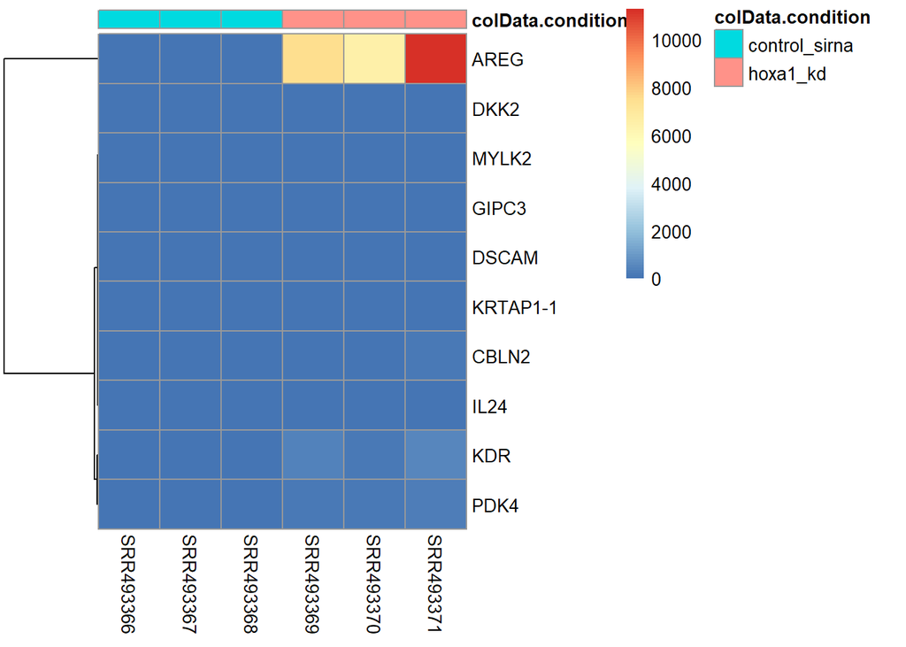

```r
annot_col = data.frame(colData$condition)
row.names(annot_col) <- rownames(colData)

pheatmap(Mat,
         cluster_rows=TRUE,
         show_rownames=TRUE,
         cluster_cols=FALSE,
         annotation_col=annot_col)
```

### Does this plot seems strange? Yes, of course!

The reason is that the data we used for count data are **unnormalized** form

In order to test for differential expression, we operate on raw counts. However for other downstream analyses – e.g. for visualization or clustering – it might be useful to work with transformed versions of the count data. Maybe the most obvious choice of transformation is the logarithm. Two alternative approaches that offer more theoretical justification: One makes use of the concept of variance stabilizing transformations (VST) (Tibshirani 1988; Huber et al. 2003; Anders and Huber 2010), and the other is the regularized logarithm or rlog, which incorporates a prior on the sample differences (Love, Huber, and Anders 2014). Both transformations produce transformed data on the log2 scale which has been normalized with respect to library size or other normalization factors.

```r
vsd <- vst(dds, blind=FALSE)
rld <- rlog(dds, blind=FALSE)
head(assay(vsd),5)
```

```
##                 SRR493366 SRR493367 SRR493368 SRR493369 SRR493370 SRR493371
## ENSG00000279457  9.311732  9.323061  9.290228  9.324480  9.298789  9.360684
## ENSG00000187634  9.759278  9.706971  9.815796  9.907678  9.867201  9.886526
## ENSG00000188976 11.530881 11.510718 11.545551 11.097930 11.065128 11.041445
## ENSG00000187961  9.746703  9.790151  9.763720  9.969033  9.951178 10.042004
## ENSG00000187583  9.319109  9.432340  9.449644  9.406741  9.400720  9.430797
```

```r
head(assay(rld),5)
```

```
##                 SRR493366 SRR493367 SRR493368 SRR493369 SRR493370 SRR493371
## ENSG00000279457  4.874137  4.915031  4.789058  4.920392  4.823518  5.061904
## ENSG00000187634  7.318326  7.156676  7.481602  7.736933  7.627583  7.682308
## ENSG00000188976 10.984085 10.956912 11.004897 10.361388 10.310598 10.273294
## ENSG00000187961  7.310663  7.435962  7.352521  7.927889  7.882805  8.115827
## ENSG00000187583  5.235421  5.644702  5.712697  5.550972  5.528182  5.643030
```

Or the third approach is to use the DESeq2 normalized data

```r
dds.factor <- estimateSizeFactors(dds)
deseq.norm <- counts(dds.factor,normalized=TRUE)
deseq.log.norm <- log2( 1 + deseq.norm)
head(deseq.log.norm,5)
```

```
##                 SRR493366 SRR493367 SRR493368 SRR493369 SRR493370 SRR493371
## ENSG00000279457  4.892417  4.983132  4.712413  4.994307  4.785358  5.266260
## ENSG00000187634  7.282934  7.082624  7.485876  7.790357  7.659787  7.722789
## ENSG00000188976 10.996988 10.968562 11.017584 10.351186 10.298725 10.260482
## ENSG00000187961  7.235937  7.395409  7.299366  7.978712  7.925016  8.189447
## ENSG00000187583  4.951792  5.741607  5.845995  5.580244  5.541001  5.732116
```

You can compare these 3 approaches to visulaize the data

```r
count.reduced <- subset(deseq.log.norm,indx)
# count.reduced <- subset(assay(vsd),indx)
# count.reduced <- subset(assay(rld),indx)


Name.up <- as.data.frame(order.up$symbol[1:5])
colnames(Name.up) <- "Gene.Name"
count.up <- count.reduced[order( res.reduced$log2FoldChange, decreasing=TRUE)[1:5], ]

Name.down <- as.data.frame(order.down$symbol[1:5])
colnames(Name.down) <- "Gene.Name"
count.down <- count.reduced[ order( res.reduced$log2FoldChange )[1:5], ]

NAME <- rbind(Name.up,Name.down)
Mat <- as.matrix(rbind(count.up,count.down))
row.names(Mat) <- NAME$Gene.Name
```

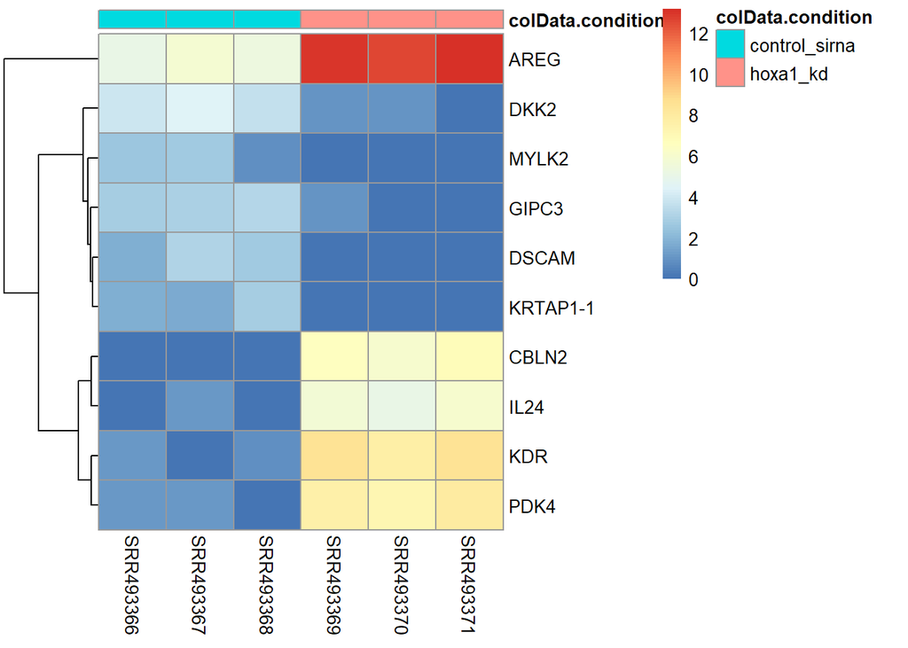

```r
annot_col = data.frame(colData$condition)
row.names(annot_col) <- rownames(colData)

pheatmap(Mat,
         cluster_rows=TRUE,
         show_rownames=TRUE,
         cluster_cols=FALSE,
         annotation_col=annot_col)
```

### Q5

```r
data(kegg.sets.hs)
data(sigmet.idx.hs)

# Focus on signaling and metabolic pathways only
kegg.sets.hs = kegg.sets.hs[sigmet.idx.hs]
```

```r
foldchanges = res.046$log2FoldChange
names(foldchanges) = res.046$entrez

#  run the gage pathway analysis
keggres = gage(foldchanges, gsets=kegg.sets.hs)


## top 1 upregulated pathways
path.top <- rownames(keggres$greater)[1]
path.top
```

```
## [1] "hsa04640 Hematopoietic cell lineage"
```

```r
## top 1 downregulated pathway
path.down <- rownames(keggres$less)[1]
path.down
```

```
## [1] "hsa04110 Cell cycle"
```